# Week 1 Data Science Capstone

Gabriela Ochoa

31 marzo 2021

# *Milestone Report Overview*

Capstone report of the Data Science specialization, we'll try to apply some data science techniques to analyze *Natural Language Processing*.

The main goal is to elaborate a text-prediction application with R Shiny package.

However, this report covers only the *EDA* of the Capstone Dataset.

*Tasks to accomplish*

1. Tokenization - identifying appropriate tokens such as words, punctuation, and numbers. Writing a function that takes a file as input and returns a tokenized version of it.
2. Profanity filtering - removing profanity and other words you do not want to predict.

*Tips, tricks, and hints*

## *Loading the data*

This dataset is fairly large. We emphasize that you don't necessarily need to load the entire dataset in to build your algorithms (see point 2 below). At least initially, you might want to use a smaller subset of the data. Reading in chunks or lines using R's readLines or scan functions can be useful. You can also loop over each line of text by embedding readLines within a for/while loop, but this may be slower than reading in large chunks at a time. Reading pieces of the file at a time will require the use of a file connection in R. For example, the following code could be used to read the first few lines of the English Twitter dataset:

- `con <- file("en_US.twitter.txt", "r")`
- `readLines(con, 1)` ## Read the first line of text
- `readLines(con, 1)` ## Read the next line of text
- `readLines(con, 5)` ## Read in the next 5 lines of text
- `close(con)` ## It's important to close the connection when you are done.

## *Sampling*

To reiterate, to build models you don't need to load in and use all of the data. Often relatively few randomly selected rows or chunks need to be included to get an accurate approximation to results that would be obtained using all the data. Remember your inference class and how a representative sample can be used to infer facts about a population.

To reiterate, to build models you don't need to load in and use all of the data. Often relatively few randomly selected rows or chunks need to be included to get an accurate approximation to results that would be obtained using all the data. Remember your inference class and how a representative sample can be used to infer facts about a population. You might want to create a separate sub-sample dataset by reading in a random subset of the original data and writing it out to a separate file. That way, you can store the sample and not have to recreate it every time. You can use the rbinom function to "flip a biased coin" to determine whether you sample a line of text or not.

### **Loading libraries**

```r
if(Sys.getenv("JAVA_HOME")!="")
      Sys.setenv(JAVA_HOME="")
library(rJava)
library(stringi)
library(openNLP)
library(qdap)
library(tm)
library(tokenizers)
library(NLP)
library(RWeka)
```

### **Loading data**

```r
# Read the blogs and twitter files using readLines
blog_data <- readLines("final/en_US/en_US.blogs.txt", warn = FALSE, encoding = "UTF-8")
twitter_data <- readLines("final/en_US/en_US.twitter.txt", warn = FALSE, encoding = "UTF-8")

# Read the news file using binary/binomial mode as there are special characters in the text
con <- file("final/en_US/en_US.news.txt", open="rb")
news_data <- readLines(con, encoding = "UTF-8")
close(con)
rm(con)
```

### **Calculating data dimensions** *Megabytes*

```r
## size of the data
blog_dim <- file.info("final/en_US/en_US.blogs.txt")$size / 1024 ^ 2
sprintf("The en_US.blogs.txt file is: %s Megabytes", blog_dim)
```

```
## [1] "The en_US.blogs.txt file is: 200.424207687378 Megabytes"
```

```r
news_dim <- file.info("final/en_US/en_US.news.txt")$size / 1024 ^ 2
sprintf("The en_US.news.txt file is: %s Megabytes", news_dim)
```

```
## [1] "The en_US.news.txt file is: 196.277512550354 Megabytes"
```

```r
twitter_dim <- file.info("final/en_US/en_US.twitter.txt")$size / 1024 ^ 2
sprintf("The en_US.twitter.txt file is: %s Megabytes", twitter_dim)
```

```
## [1] "The en_US.twitter.txt file is: 159.364068984985 Megabytes"
```

### **Data Summary**

```r
Data_info <- data.frame('File' = c("Blogs","News","Twitter"),
                      "FileSizeinMB" = c(blog_dim, news_dim, twitter_dim),
                      'NumberofLines' = sapply(list(blog_data, news_data, twitter_data), function(x){length(x)}),
                      'TotalCharacters' = sapply(list(blog_data, news_data, twitter_data), function(x){sum(nchar(x))}),
                      TotalWords = sapply(list(blog_data,news_data,twitter_data),stri_stats_latex)[4,],
                      'MaxCharacters' = sapply(list(blog_data, news_data, twitter_data), function(x){max(unlist(lapply(x, function(y) nchar(y))))})
                      )

Data_info
```

```
##      File FileSizeinMB NumberofLines TotalCharacters TotalWords MaxCharacters
## 1   Blogs     200.4242        899288       206824505   37570839         40833
## 2    News     196.2775       1010242       203223159   34494539         11384
## 3 Twitter     159.3641       2360148       162096031   30451128           140
```

### **Counting words**

In the `en_US twitter data set`, if you divide the number of lines where the word `"love"` (all lowercase) occurs by the number of lines the word `"hate"` (all lowercase) occurs, about what do you get?

```r
love_hate<-length(grep("love", twitter_data))/length(grep("hate", twitter_data))
sprintf("We get around: %s", love_hate)
```

```
## [1] "We get around: 4.10859156202006"
```

The one tweet in the `en_US twitter data set` that matches the word `"biostats"` says what?

```r
tweet<-grep("biostats", twitter_data, value=TRUE)
tweet
```

```
## [1] "i know how you feel.. i have biostats on tuesday and i have yet to study =/"
```

How many tweets have the exact characters `"A computer once beat me at chess, but it was no match for me at kickboxing"`. (I.e. the line matches those characters exactly.)

```r
tweet_match<-grep("A computer once beat me at chess, but it was no match for me at kickboxing", twitter_data)
tweet_match
```

```
## [1]  519059  835824 2283423
```

# *Task 2 - Exploratory Data Analysis* & **Task 3 - Modeling**

The first step in building a predictive model for text is understanding the distribution and relationship between the words, tokens, and phrases in the text. The goal of this task is to understand the basic relationships you observe in the data and prepare to build your first linguistic models.

*Tasks to accomplish*

1. **Exploratory analysis** perform a thorough exploratory analysis of the data, understanding the distribution of words and relationship between the words in the corpora.
2. **Understand frequencies of words and word pairs** build figures and tables to understand variation in the frequencies of words and word pairs in the data.

*Questions to consider*

1. Some words are more frequent than others - what are the distributions of word frequencies?
2. What are the frequencies of 2-grams and 3-grams in the dataset?
3. How many unique words do you need in a frequency sorted dictionary to cover 50% of all word instances in the language? 90%?
4. How do you evaluate how many of the words come from foreign languages?
5. Can you think of a way to increase the coverage -- identifying words that may not be in the corpora or using a smaller number of words in the dictionary to cover the same number of phrases?

*Questions to consider*

1. How can you efficiently store an n-gram model (think Markov Chains)?
2. How can you use the knowledge about word frequencies to make your model smaller and more efficient?
3. How many parameters do you need (i.e. how big is n in your n-gram model)?
4. Can you think of simple ways to "smooth" the probabilities (think about giving all n-grams a non-zero probability even if they aren't observed in the data) ?
5. How do you evaluate whether your model is any good?
6. How can you use backoff models to estimate the probability of unobserved n-grams?

Using *Tidy Data* methodology we can perform some EDA. We can use a simple Word Cloud to visualize the most frequent words.

```r
blogsmp <- sample(blog_data,1000)
newsmp <- sample(news_data,1000)
twittersmp <- sample(twitter_data,1000)
sample <- c(blogsmp,newsmp,twittersmp)
txt <- sent_detect(sample)
remove(blogsmp,newsmp,twittersmp,blog_data,news_data,twitter_data,sample)
```

Now we remove what we won't be needing

```r
txt <- removeNumbers(txt)
txt <- removePunctuation(txt)
txt <- stripWhitespace(txt)
txt <- tolower(txt)
txt <- txt[which(txt!="")]
txt <- data.frame(txt,stringsAsFactors = FALSE)
```

We now create some word clouds to visualize the most frequent words and order data frames of 1-grams, 2-grams, 3-grams

```r
words<-WordTokenizer(txt)
grams<-NGramTokenizer(txt)

for(i in 1:length(grams))
{if(length(WordTokenizer(grams[i]))==2) break}
for(j in 1:length(grams))
{if(length(WordTokenizer(grams[j]))==1) break}

onegrams <- data.frame(table(words))
onegrams <- onegrams[order(onegrams$Freq, decreasing = TRUE),]
bigrams <- data.frame(table(grams[i:(j-1)]))
bigrams <- bigrams[order(bigrams$Freq, decreasing = TRUE),]
trigrams <- data.frame(table(grams[1:(i-1)]))
trigrams <- trigrams[order(trigrams$Freq, decreasing = TRUE),]
remove(i,j,grams)
```

### *Word cloud*

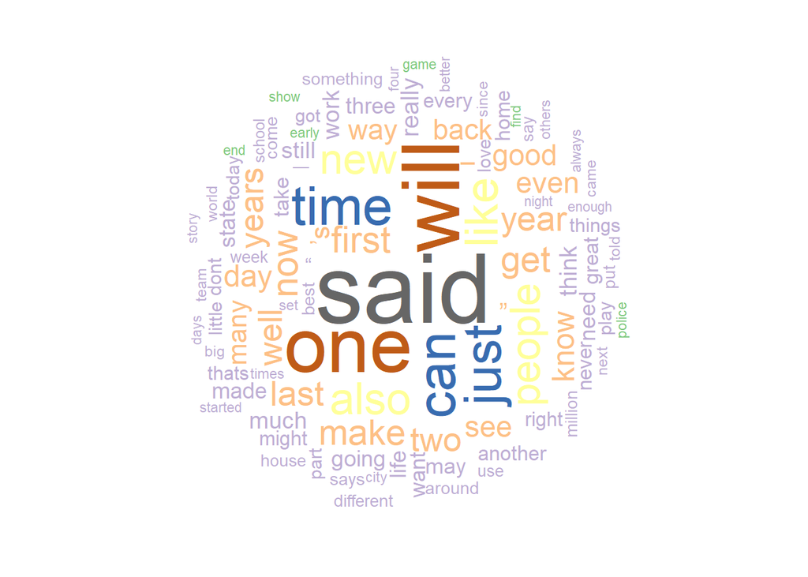

```r
library(wordcloud)
wordcloud(words, scale=c(5,0.1), max.words=100, random.order=FALSE,
          rot.per=0.5, use.r.layout=FALSE, colors=brewer.pal(8,"Accent"))
```

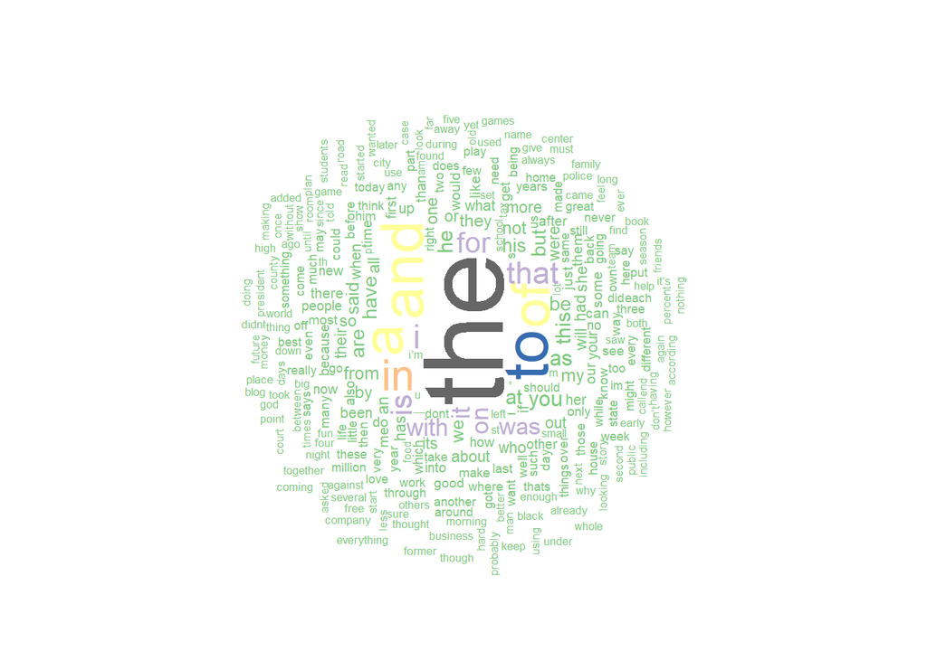

```r
wordcloud(onegrams$words, onegrams$Freq, scale=c(5,0.5), max.words=300, random.order=FALSE,
          rot.per=0.5, use.r.layout=FALSE, colors=brewer.pal(8,"Accent"))
```

The first graph shows the distribution of words in the corpora except such words, as "the", "a", "of", "to", etc. The second graph - the distribution of all single wors. The frequences lay between 3796 to 1.

What are the frequencies of 2-grams and 3-grams in the dataset?

## *Some Barplot*

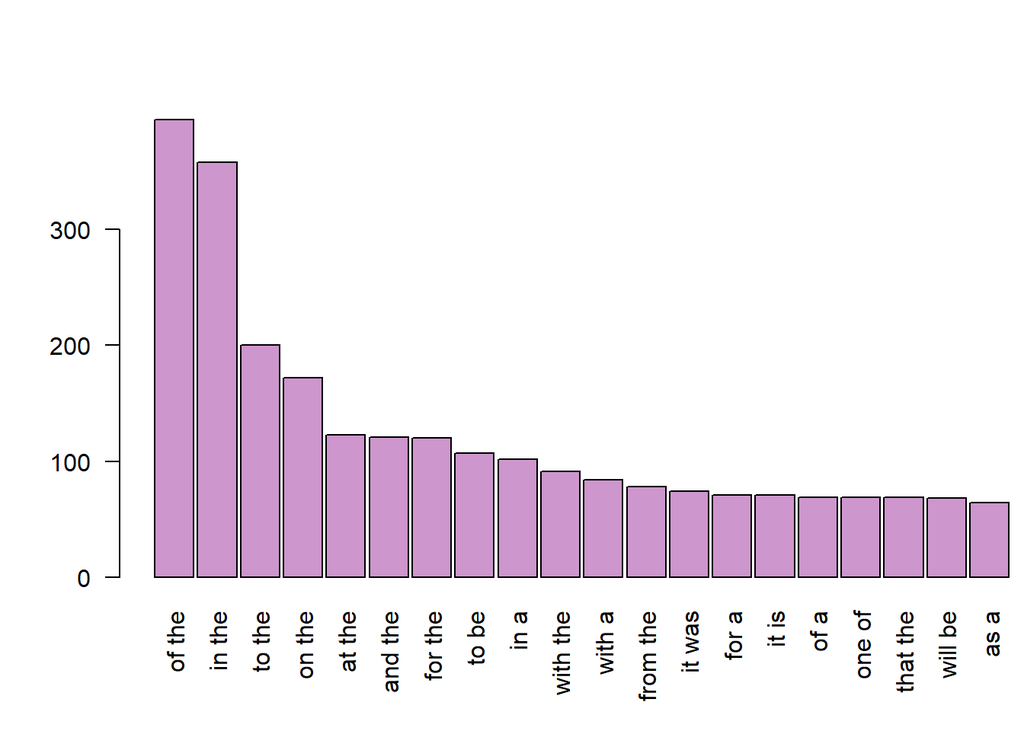

```r
barplot(bigrams[1:20,2],col="plum3",
        names.arg = bigrams$Var1[1:20],srt = 45,
        space=0.1, xlim=c(0,20),las=2)
```

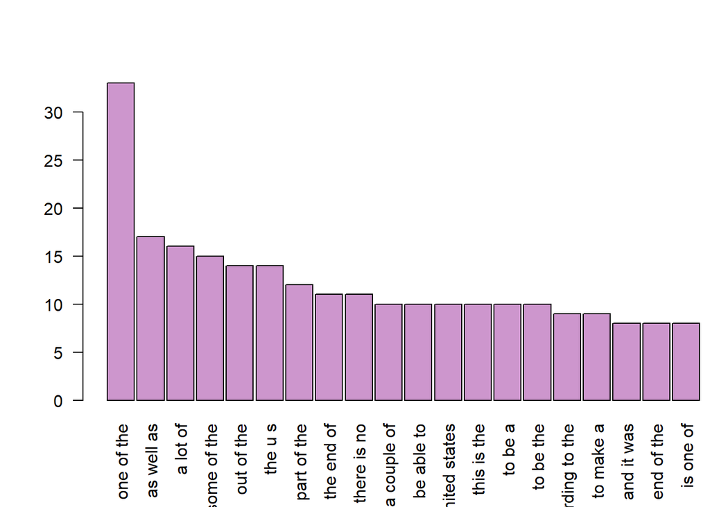

```r
barplot(trigrams[1:20,2],col="plum3",
        names.arg = trigrams$Var1[1:20],srt = 45,
        space=0.1, xlim=c(0,20),las=2)
```

As you develop your prediction model, two key aspects that you will have to keep in mind are the size and runtime of the algorithm. These are defined as:

1. **Size:** the amount of memory (physical `RAM`) required to run the model in R
2. **Runtime:** The amount of time the algorithm takes to make a prediction given the acceptable input

The goal for this prediction model is to minimize both the size and runtime of the model in order to provide a reasonable experience to the user.

Keep in mind that currently available predictive text models can run on mobile phones, which typically have limited memory and processing power compared to desktop computers. Therefore, you should consider very carefully (1) how much memory is being used by the objects in your workspace; and (2) how much time it is taking to run your model. Ultimately, your model will need to run in a Shiny app that runs on the shinyapps.io server.

*Extra Tips, tricks, and hints*

Here are a few tools that may be of use to you as you work on their algorithm:

- `object.size()`: this function reports the number of bytes that an R object occupies in memory
- `Rprof()`: this function runs the profiler in R that can be used to determine where bottlenecks in your function may exist. The profr package (available on CRAN) provides some additional tools for visualizing and summarizing profiling data.
- `gc()`: this function runs the garbage collector to retrieve unused RAM for R. In the process it tells you how much memory is currently being used by R.

There will likely be a tradeoff that you have to make in between size and runtime. For example, an algorithm that requires a lot of memory, may run faster, while a slower algorithm may require less memory. You will have to find the right balance between the two in order to provide a good experience to the user.